# Tugas-Pertemuan-1

Nabeel Muhammad Diaz

## Deskripsi Data

Data yang digunakan kelompok adalah **Daily Total Sunspot Number** (bilangan bintik matahari harian) dari **SILSO**, World Data Center, Royal Observatory of Belgium (https://www.sidc.be/SILSO/datafiles). Bilangan bintik matahari adalah indeks aktivitas magnetik permukaan Matahari yang dihitung dari jumlah bintik dan kelompok bintik yang teramati.

Kelompok memilih **500 observasi harian terakhir** dari data tersebut, lalu dibagi rata kepada 5 anggota sehingga masing-masing memperoleh 100 observasi. Laporan ini mengerjakan **bagian ke-2, yaitu observasi ke-101 hingga ke-200**, yang mencakup periode **27 Juni 2025 sampai 4 Oktober 2025**.

## Library/Packages

*Package* R yang akan digunakan pada perkuliahan Analisis Deret Waktu sesi UTS adalah: `forecast`, `graphics`, `TTR`, `TSA` . Jika *package* tersebut belum ada, silakan install terlebih dahulu.

```r
#install.packages("forecast")
#install.packages("graphics")
#install.packages("TTR")
#install.packages("TSA")
```

Jika sudah ada, silakan panggil library *package* tersebut.

```r
library("forecast")
library("graphics")
library("TTR")
library("TSA")
```

## Impor Data

```r
#via csv gunakan read.csv("namafile.csv")
data1 <- read.csv("data/sunspot_bagian2.csv")

# menampilkan 6 data pertama
head(data1)
```

```
##   Periode    Tanggal Sunspot
## 1       1 2025-06-27     116
## 2       2 2025-06-28     136
## 3       3 2025-06-29     151
## 4       4 2025-06-30     150
## 5       5 2025-07-01     147
## 6       6 2025-07-02     137
```

## Eksplorasi Data

`View()` : menampilkan data dalam bentuk tabel, `str()` : menampilkan struktur data, `dim()` : menampilkan dimensi data

```r
#View(data1)
str(data1)
```

```
## 'data.frame':    100 obs. of  3 variables:
##  $ Periode: int  1 2 3 4 5 6 7 8 9 10 ...
##  $ Tanggal: chr  "2025-06-27" "2025-06-28" "2025-06-29" "2025-06-30" ...
##  $ Sunspot: int  116 136 151 150 147 137 116 100 76 87 ...
```

```r
dim(data1)
```

```
## [1] 100   3
```

Mengubah data agar terbaca sebagai data deret waktu dengan fungsi `ts()` .

```r
data1.ts <- ts(data1$Sunspot)
```

Menampilkan ringkasan data

```r
summary(data1.ts)
```

```
##    Min. 1st Qu.  Median    Mean 3rd Qu.    Max.
##    36.0   107.0   137.5   131.6   161.2   204.0
```

Membuat plot data deret waktu

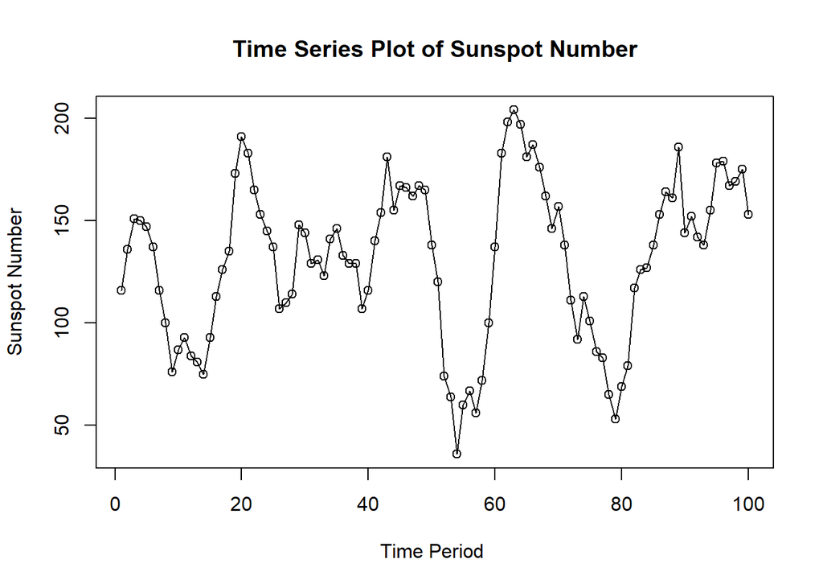

```r
ts.plot(data1.ts, xlab="Time Period ", ylab="Sunspot Number",
        main = "Time Series Plot of Sunspot Number")
points(data1.ts)
```

Plot deret waktu menunjukkan data berfluktuasi tajam dari hari ke hari dengan rentang nilai 36 hingga 204 dan rata-rata 131,56. Terdapat kecenderungan naik yang lemah sepanjang periode pengamatan, namun tidak berupa tren linear yang persisten. Fluktuasi harian yang besar merupakan ciri khas data aktivitas matahari karena bintik matahari muncul dan menghilang dalam hitungan hari.

## Single Moving Average & Double Moving Average

### Pembagian Data

Pembagian data latih dan data uji dilakukan dengan perbandingan 80% data latih dan 20% data uji.

```r
# hitung jumlah data
n <- nrow(data1)

# tentukan batas 80%
n_train <- floor(0.8 * n)

# bagi data
training_ma <- data1[1:n_train, ]
testing_ma  <- data1[(n_train+1):n, ]

# ubah ke time series
train_ma.ts <- ts(training_ma$Sunspot)
test_ma.ts  <- ts(testing_ma$Sunspot)

# banyaknya data uji
n_test <- nrow(testing_ma)
c(n = n, n_train = n_train, n_test = n_test)
```

```
##       n n_train  n_test
##     100      80      20
```

Eksplorasi data dilakukan pada keseluruhan data, data latih serta data uji menggunakan plot data deret waktu.

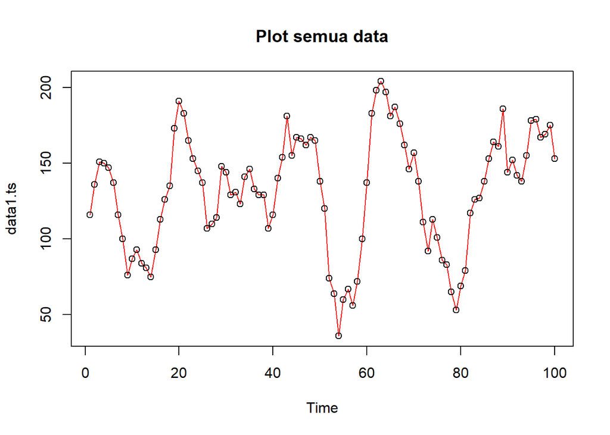

```r
#eksplorasi keseluruhan data
plot(data1.ts, col="red",main="Plot semua data")
points(data1.ts)
```

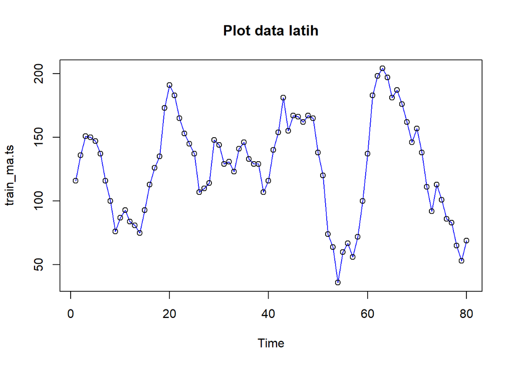

```r
#eksplorasi data latih
plot(train_ma.ts, col="blue",main="Plot data latih")
points(train_ma.ts)
```

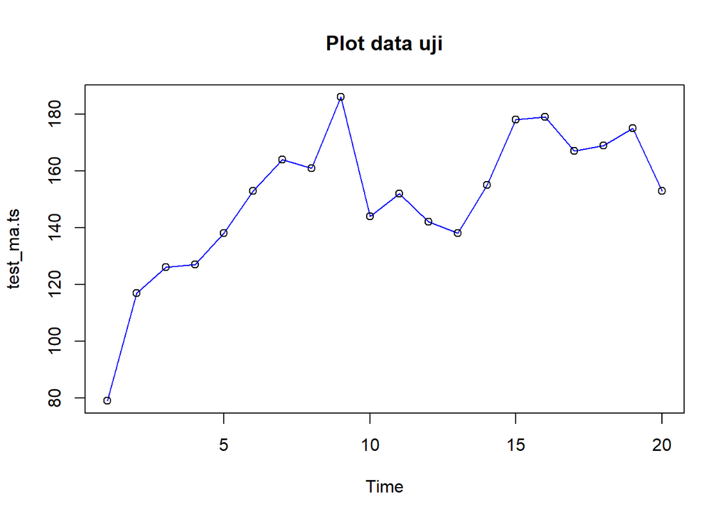

```r
#eksplorasi data uji
plot(test_ma.ts, col="blue",main="Plot data uji")
points(test_ma.ts)
```

Eksplorasi data juga dapat dilakukan menggunakan package `ggplot2` dengan terlebih dahulu memanggil library *package* `ggplot2`.

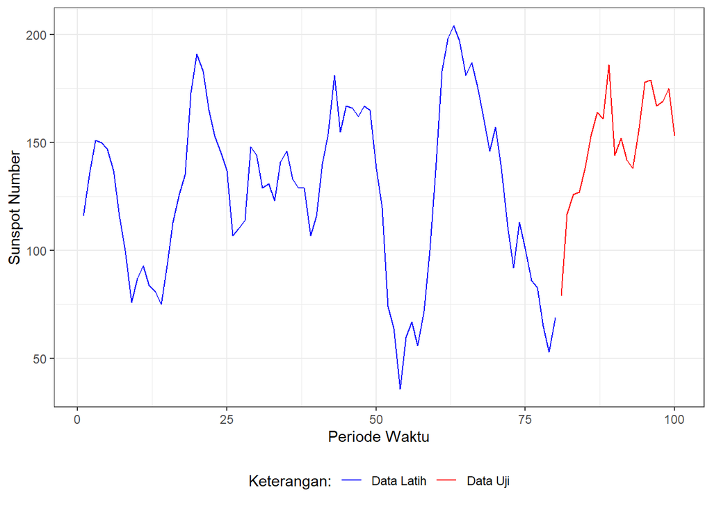

```r
library(ggplot2)
ggplot() +
  geom_line(data = training_ma, aes(x = Periode, y = Sunspot, col = "Data Latih")) +
  geom_line(data = testing_ma, aes(x = Periode, y = Sunspot, col = "Data Uji")) +
  labs(x = "Periode Waktu", y = "Sunspot Number", color = "Legend") +
   scale_colour_manual(name="Keterangan:", breaks = c("Data Latih", "Data Uji"),
                      values = c("blue", "red")) +
  theme_bw() + theme(legend.position = "bottom",
                     plot.caption = element_text(hjust=0.5, size=12))
```

Terlihat bahwa rata-rata data uji (150,15) lebih tinggi daripada rata-rata data latih (126,91), sehingga terdapat pergeseran level antara kedua bagian data.

### Single Moving Average (SMA)

Ide dasar dari Single Moving Average (SMA) adalah data suatu periode dipengaruhi oleh data periode sebelumnya. Metode pemulusan ini cocok digunakan untuk pola data stasioner atau konstan. Prinsip dasar metode pemulusan ini adalah data pemulusan pada periode ke-t merupakan rata rata dari m buah data pada periode ke-t hingga periode ke (t-m+1).

$$S_t = \frac{1}{m} \sum_{i=t-m+1}^{t} X_i$$

Data pemulusan pada periode ke-t selanjutnya digunakan sebagai nilai peramalan pada periode ke t+1.

$$F_t = S_{t-1}, F_{n,h} = S_n$$

Pemulusan menggunakan metode SMA dilakukan dengan fungsi `SMA()`. Dalam hal ini akan dilakukan pemulusan dengan parameter `m=4`.

```r
data.sma<-SMA(train_ma.ts, n=4)
data.sma
```

```
## Time Series:
## Start = 1
## End = 80
## Frequency = 1
##  [1]     NA     NA     NA 138.25 146.00 146.25 137.50 125.00 107.25  94.75
## [11]  89.00  85.00  86.25  83.25  83.25  90.50 101.75 116.75 136.75 156.25
## [21] 170.50 178.00 173.00 161.50 150.00 135.50 124.75 117.00 119.75 129.00
## [31] 133.75 138.00 131.75 131.00 135.25 135.75 137.25 134.25 124.50 120.25
## [41] 123.00 129.25 147.75 157.50 164.25 167.25 162.50 165.50 165.00 158.00
## [51] 147.50 124.25  99.00  73.50  58.50  56.75  54.75  63.75  73.75  91.25
## [61] 123.00 154.50 180.50 195.50 195.00 192.25 185.25 176.50 167.75 160.25
## [71] 150.75 138.00 124.50 113.50 104.25  98.00  95.75  83.75  71.75  67.50
```

Data pemulusan pada periode ke-t selanjutnya digunakan sebagai nilai peramalan pada periode ke t+1 sehingga hasil peramalan 1 periode kedepan adalah sebagai berikut.

```r
data.ramal<-c(NA,data.sma)
data.ramal #forecast 1 periode ke depan
```

```
##  [1]     NA     NA     NA     NA 138.25 146.00 146.25 137.50 125.00 107.25
## [11]  94.75  89.00  85.00  86.25  83.25  83.25  90.50 101.75 116.75 136.75
## [21] 156.25 170.50 178.00 173.00 161.50 150.00 135.50 124.75 117.00 119.75
## [31] 129.00 133.75 138.00 131.75 131.00 135.25 135.75 137.25 134.25 124.50
## [41] 120.25 123.00 129.25 147.75 157.50 164.25 167.25 162.50 165.50 165.00
## [51] 158.00 147.50 124.25  99.00  73.50  58.50  56.75  54.75  63.75  73.75
## [61]  91.25 123.00 154.50 180.50 195.50 195.00 192.25 185.25 176.50 167.75
## [71] 160.25 150.75 138.00 124.50 113.50 104.25  98.00  95.75  83.75  71.75
## [81]  67.50
```

Selanjutnya dilakukan peramalan sebanyak 20 periode sesuai dengan jumlah data uji. Pada metode SMA, seluruh hasil peramalan untuk 20 periode ke depan akan memiliki nilai yang sama dengan hasil ramalan satu periode ke depan.

```r
data.gab<-cbind(
  aktual=c(data1.ts),
  pemulusan=c(data.sma,rep(NA,n_test)),
  ramalan=c(data.ramal,rep(data.ramal[length(data.ramal)],n_test-1)))

data.gab #forecast 20 periode ke depan
```

```
##        aktual pemulusan ramalan
##   [1,]    116        NA      NA
##   [2,]    136        NA      NA
##   [3,]    151        NA      NA
##   [4,]    150    138.25      NA
##   [5,]    147    146.00  138.25
##   [6,]    137    146.25  146.00
##   [7,]    116    137.50  146.25
##   [8,]    100    125.00  137.50
##   [9,]     76    107.25  125.00
##  [10,]     87     94.75  107.25
##  [11,]     93     89.00   94.75
##  [12,]     84     85.00   89.00
##  [13,]     81     86.25   85.00
##  [14,]     75     83.25   86.25
```

[output cut: 86 more lines]

Adapun plot data deret waktu dari hasil peramalan yang dilakukan adalah sebagai berikut.

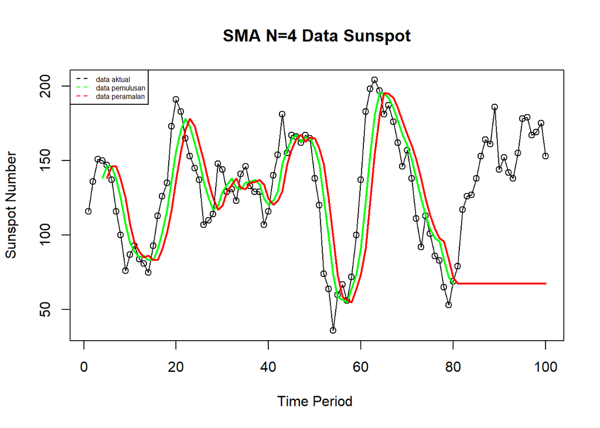

```r
ts.plot(data1.ts, xlab="Time Period ", ylab="Sunspot Number", main= "SMA N=4 Data Sunspot")
points(data1.ts)
lines(data.gab[,2],col="green",lwd=2)
lines(data.gab[,3],col="red",lwd=2)
legend("topleft",c("data aktual","data pemulusan","data peramalan"), lty=8, col=c("black","green","red"), cex=0.5)
```

Selanjutnya perhitungan akurasi dilakukan dengan ukuran akurasi *Sum Squares Error* (SSE), *Mean Square Error* (MSE) dan *Mean Absolute Percentage Error* (MAPE). Perhitungan akurasi dilakukan baik pada data latih maupun pada data uji.

$$SSE = \sum_{t=1}^{n} (y_t - \hat{y}_t)^2$$
$$MSE = \frac{1}{n} \sum_{t=1}^{n} (y_t - \hat{y}_t)^2$$
$$MAPE = \frac{1}{n} \sum_{t=1}^{n} \left|\frac{y_t -
\hat{y}_t}{y_t}\right| * 100$$

```r
#Menghitung nilai keakuratan data latih
error_train.sma = train_ma.ts-data.ramal[1:length(train_ma.ts)]

SSE_train.sma = sum(error_train.sma[5:length(train_ma.ts)]^2)
MSE_train.sma = mean(error_train.sma[5:length(train_ma.ts)]^2)
MAPE_train.sma = mean(abs((error_train.sma[5:length(train_ma.ts)]/train_ma.ts[5:length(train_ma.ts)])*100))

akurasi_train.sma <- matrix(c(SSE_train.sma, MSE_train.sma, MAPE_train.sma))
row.names(akurasi_train.sma)<- c("SSE", "MSE", "MAPE")
colnames(akurasi_train.sma) <- c("Akurasi m = 4")
akurasi_train.sma
```

```
##      Akurasi m = 4
## SSE    74400.43750
## MSE      978.95312
## MAPE      22.39358
```

Dalam hal ini nilai MAPE data latih pada metode pemulusan SMA sekitar 22%, nilai ini dikategorikan sebagai akurasi yang cukup/layak namun belum baik. Berbeda dengan data penjualan yang relatif mulus, data bintik matahari berfluktuasi sangat tajam antar hari sehingga sulit dimuluskan hanya dengan rata-rata bergerak. Selanjutnya dilakukan perhitungan nilai MAPE data uji pada metode pemulusan SMA.

```r
#Menghitung nilai keakuratan data uji
error_test.sma = test_ma.ts-data.gab[(n_train+1):n,3]

SSE_test.sma = sum(error_test.sma^2)
MSE_test.sma = mean(error_test.sma^2)
MAPE_test.sma = mean(abs((error_test.sma/test_ma.ts*100)))

akurasi_test.sma <- matrix(c(SSE_test.sma, MSE_test.sma, MAPE_test.sma))
row.names(akurasi_test.sma)<- c("SSE", "MSE", "MAPE")
colnames(akurasi_test.sma) <- c("Akurasi m = 4")
akurasi_test.sma
```

```
##      Akurasi m = 4
## SSE   148803.00000
## MSE     7440.15000
## MAPE      53.38896
```

Perhitungan akurasi pada data uji menghasilkan nilai MAPE sekitar 53%, jauh lebih besar daripada data latih. Penyebabnya adalah ramalan SMA bersifat konstan untuk seluruh horizon peramalan, sedangkan data aktual pada periode uji justru mengalami kenaikan level. Akibatnya galat menumpuk seiring bertambahnya horizon peramalan.

### Double Moving Average (DMA)

Metode pemulusan Double Moving Average (DMA) pada dasarnya mirip dengan SMA. Namun demikian, metode ini lebih cocok digunakan untuk pola data trend. Proses pemulusan dengan rata rata dalam metode ini dilakukan sebanyak 2 kali.

- **Tahap I:**

$$S_{1,t} = \frac{1}{m} \sum_{i=t-m+1}^{t} X_i$$

- **Tahap II:**

$$S_{2,t} = \frac{1}{m} \sum_{i=t-m+1}^{t} S_{1,i}$$

Forecast $h$ langkah ke depan dihitung dengan:

$$F_{2,t,t+h} = A_t + B_t \,(h)$$

dengan komponen level ($A_t$) dan tren ($B_t$):

$$A_t = 2S_{1,t} - S_{2,t}
\qquad\text{dan}\qquad
B_t = \frac{2}{m-1}\,\big(S_{1,t} - S_{2,t}\big)$$

```r
dma <- SMA(data.sma, n = 4)
At <- 2*data.sma - dma
Bt <- 2/(4-1)*(data.sma - dma)
data.dma<- At+Bt
data.ramal2<- c(NA, data.dma)

t = 1:n_test
f = c()

for (i in t) {
  f[i] = At[length(At)] + Bt[length(Bt)]*(i)
}

data.gab2 <- cbind(aktual = c(data1.ts),
                   pemulusan1 = c(data.sma,rep(NA,n_test)),
                   pemulusan2 = c(dma, rep(NA,n_test)),
                   At = c(At, rep(NA,n_test)),
                   Bt = c(Bt,rep(NA,n_test)),
                   ramalan = c(data.ramal2, f[-1]))
data.gab2
```

```
##        aktual pemulusan1 pemulusan2       At           Bt     ramalan
##   [1,]    116         NA         NA       NA           NA          NA
##   [2,]    136         NA         NA       NA           NA          NA
##   [3,]    151         NA         NA       NA           NA          NA
##   [4,]    150     138.25         NA       NA           NA          NA
##   [5,]    147     146.00         NA       NA           NA          NA
##   [6,]    137     146.25         NA       NA           NA          NA
##   [7,]    116     137.50   142.0000 133.0000  -3.00000000          NA
##   [8,]    100     125.00   138.6875 111.3125  -9.12500000  130.000000
##   [9,]     76     107.25   129.0000  85.5000 -14.50000000  102.187500
##  [10,]     87      94.75   116.1250  73.3750 -14.25000000   71.000000
##  [11,]     93      89.00   104.0000  74.0000 -10.00000000   59.125000
##  [12,]     84      85.00    94.0000  76.0000  -6.00000000   64.000000
##  [13,]     81      86.25    88.7500  83.7500  -1.66666667   70.000000
##  [14,]     75      83.25    85.8750  80.6250  -1.75000000   82.083333
```

[output cut: 86 more lines]

Hasil pemulusan menggunakan metode DMA divisualisasikan sebagai berikut

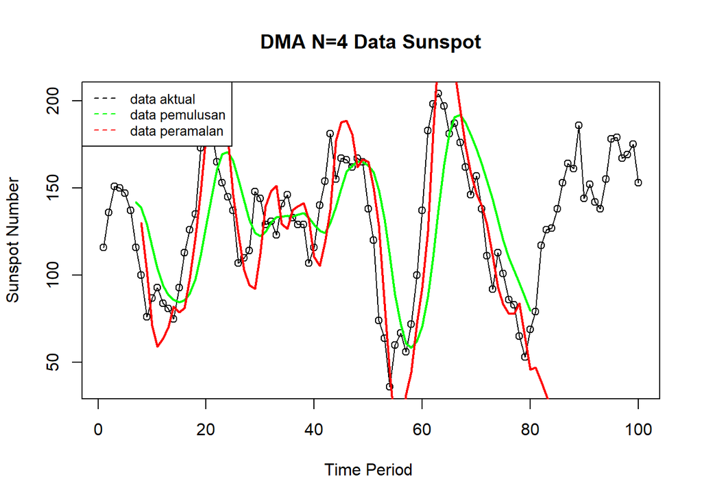

```r
ts.plot(data1.ts, xlab="Time Period ", ylab="Sunspot Number", main= "DMA N=4 Data Sunspot")
points(data1.ts)
lines(data.gab2[,3],col="green",lwd=2)
lines(data.gab2[,6],col="red",lwd=2)
legend("topleft",c("data aktual","data pemulusan","data peramalan"), lty=8, col=c("black","green","red"), cex=0.8)
```

Selanjutnya perhitungan akurasi dilakukan baik pada data latih maupun data uji. Perhitungan akurasi dilakukan dengan ukuran akurasi SSE, MSE dan MAPE.

```r
#Menghitung nilai keakuratan data latih
error_train.dma = train_ma.ts-data.ramal2[1:length(train_ma.ts)]

SSE_train.dma = sum(error_train.dma[8:length(train_ma.ts)]^2)
MSE_train.dma = mean(error_train.dma[8:length(train_ma.ts)]^2)
MAPE_train.dma = mean(abs((error_train.dma[8:length(train_ma.ts)]/train_ma.ts[8:length(train_ma.ts)])*100))

akurasi_train.dma <- matrix(c(SSE_train.dma, MSE_train.dma, MAPE_train.dma))
row.names(akurasi_train.dma)<- c("SSE", "MSE", "MAPE")
colnames(akurasi_train.dma) <- c("Akurasi m = 4")
akurasi_train.dma
```

```
##      Akurasi m = 4
## SSE    58054.35764
## MSE      795.26517
## MAPE      20.96561
```

Perhitungan akurasi pada data latih menghasilkan nilai MAPE sekitar 21%, sedikit lebih kecil daripada SMA. Hal ini menunjukkan penambahan komponen tren membantu model mengikuti pergerakan data pada data latih. Selanjutnya, perhitungan nilai akurasi dilakukan pada data uji.

```r
#Menghitung nilai keakuratan data uji
error_test.dma = test_ma.ts-data.gab2[(n_train+1):n,6]
SSE_test.dma = sum(error_test.dma^2)
MSE_test.dma = mean(error_test.dma^2)
MAPE_test.dma = mean(abs((error_test.dma/test_ma.ts*100)))

akurasi_test.dma <- matrix(c(SSE_test.dma, MSE_test.dma, MAPE_test.dma))
row.names(akurasi_test.dma)<- c("SSE", "MSE", "MAPE")
colnames(akurasi_test.dma) <- c("Akurasi m = 4")
akurasi_test.dma
```

```
##      Akurasi m = 4
## SSE    737102.7656
## MSE     36855.1383
## MAPE      115.9726
```

Berbeda dengan data latih, perhitungan akurasi pada data uji menghasilkan nilai MAPE yang sangat besar, yaitu sekitar 116%. Penyebabnya dapat dilihat dari nilai $B_t$ pada akhir data latih yang bernilai negatif (sekitar $-8{,}1$), sehingga ramalan diekstrapolasi menurun secara linear. Ramalan periode pertama masih bernilai sekitar 47, tetapi pada periode ke-20 nilainya turun hingga sekitar $-107$, padahal bilangan bintik matahari tidak mungkin bernilai negatif. Hal ini menunjukkan bahwa ekstrapolasi tren linear tidak sesuai untuk data yang berosilasi seperti bintik matahari.

Pada data latih, metode DMA lebih baik dibandingkan dengan metode SMA, sedangkan pada data uji, metode SMA jauh lebih baik dibandingkan DMA.

## Single Exponential Smoothing & Double Exponential Smoothing

Metode Exponential Smoothing merupakan metode pemulusan deret waktu dengan memberikan bobot yang menurun secara eksponensial pada data historis, di mana nilai terbaru mendapat bobot lebih besar dibanding nilai yang lebih lama. Metode ini menggunakan satu atau lebih parameter pemulusan yang secara langsung menentukan besar kecilnya bobot setiap pengamatan. Pemilihan parameter yang tepat akan sangat berpengaruh terhadap hasil ramalan. Secara umum, Exponential Smoothing dibedakan menjadi dua jenis, yaitu model tunggal (single) yang digunakan untuk data tanpa tren maupun musiman, serta model ganda (double) yang mampu menangkap adanya tren pada data.

### Pembagian Data

Pembagian data latih dan data uji dilakukan dengan perbandingan 80% data latih dan 20% data uji.

```r
# jumlah baris data
n <- nrow(data1)

# hitung batas 80%
n_train <- floor(0.8 * n)

# bagi data
training <- data1[1:n_train, ]
testing  <- data1[(n_train+1):n, ]

# ubah ke time series
train.ts <- ts(training$Sunspot)
test.ts  <- ts(testing$Sunspot)
```

### Eksplorasi

Eksplorasi dilakukan dengan membuat plot data deret waktu untuk keseluruhan data, data latih, dan data uji.

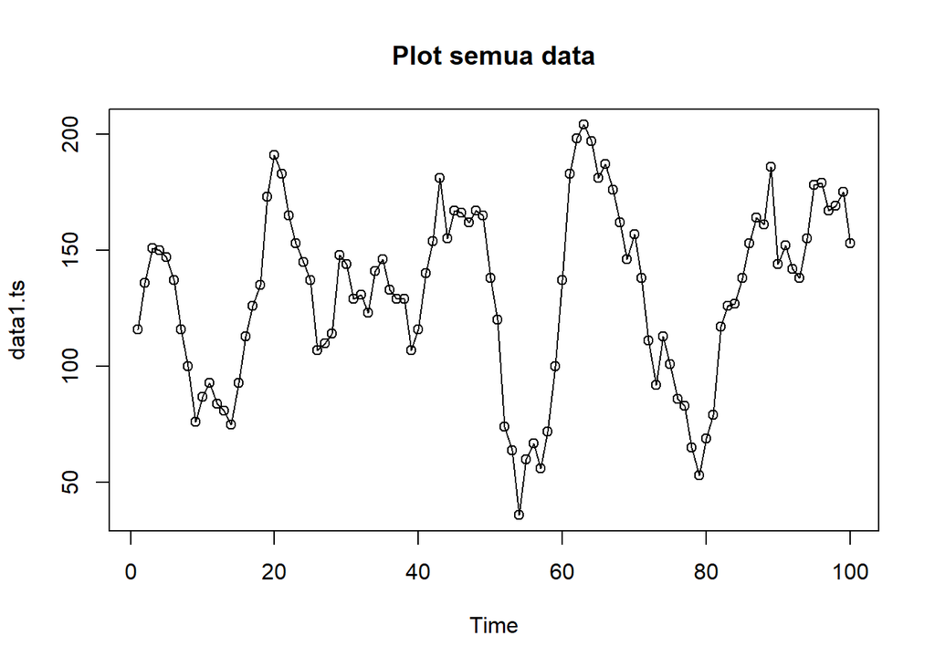

```r
#eksplorasi data
plot(data1.ts, col="black",main="Plot semua data")
points(data1.ts)
```

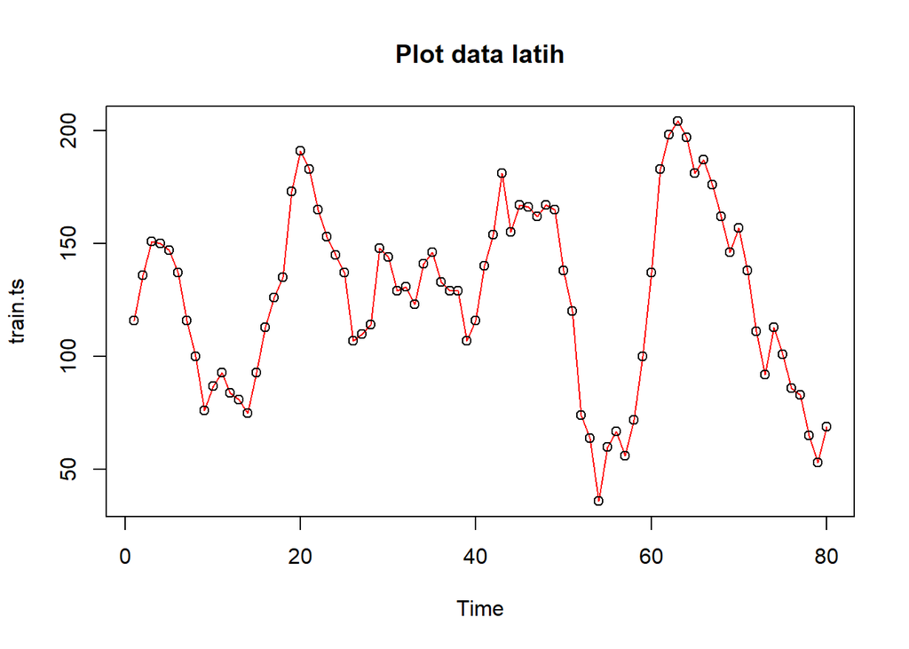

```r
plot(train.ts, col="red",main="Plot data latih")
points(train.ts)
```

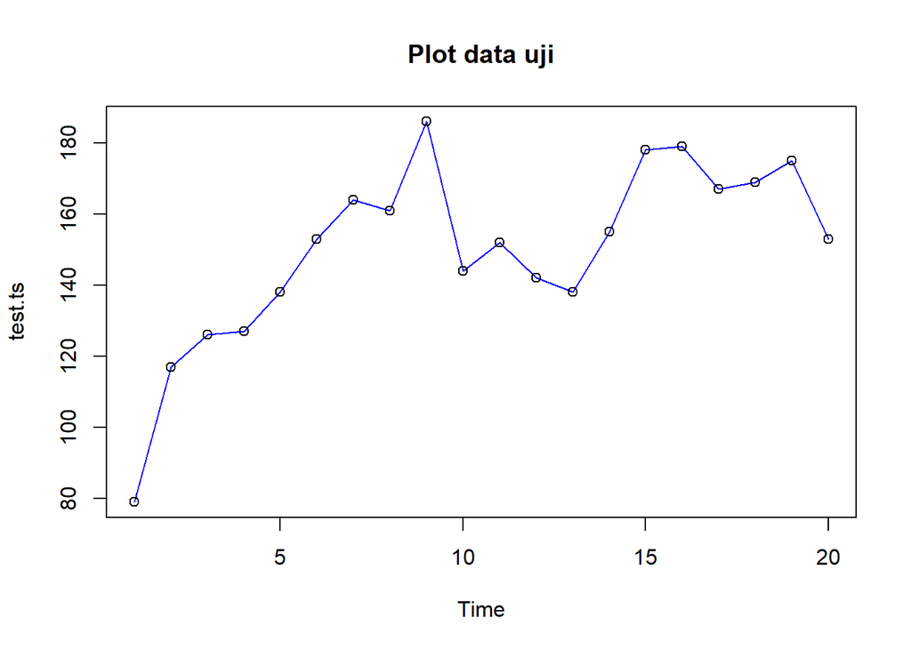

```r
plot(test.ts, col="blue",main="Plot data uji")
points(test.ts)
```

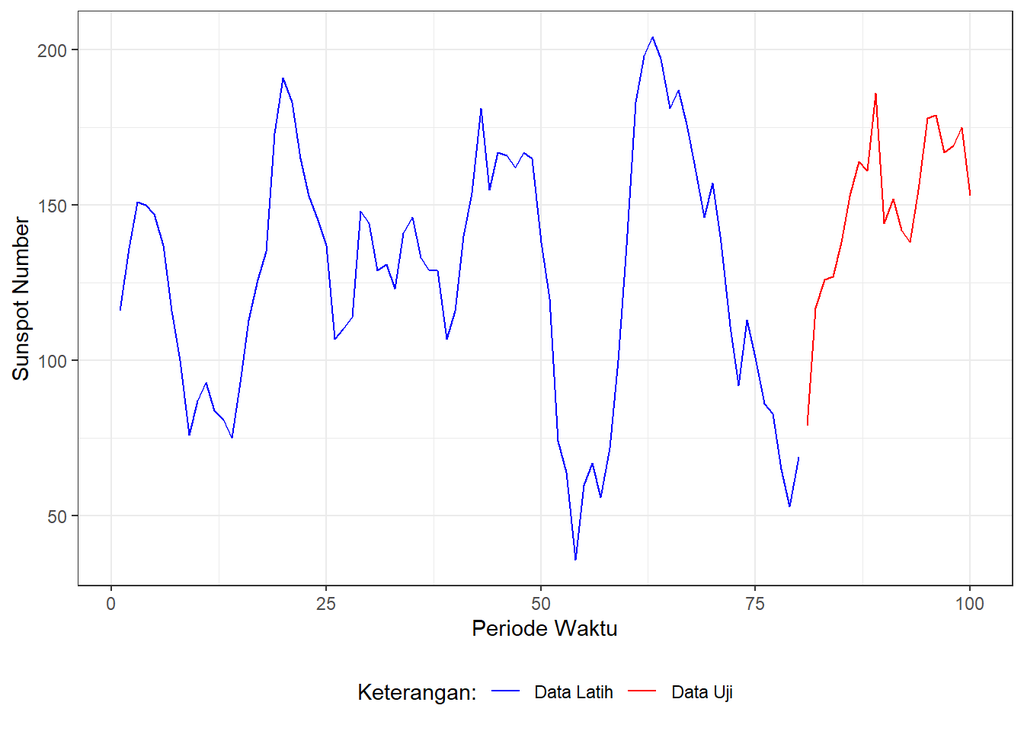

```r
#Eksplorasi dengan GGPLOT
library(ggplot2)
ggplot() +
  geom_line(data = training, aes(x = Periode, y = Sunspot, col = "Data Latih")) +
  geom_line(data = testing, aes(x = Periode, y = Sunspot, col = "Data Uji")) +
  labs(x = "Periode Waktu", y = "Sunspot Number", color = "Legend") +
  scale_colour_manual(name="Keterangan:", breaks = c("Data Latih", "Data Uji"),
                      values = c("blue", "red")) +
  theme_bw() + theme(legend.position = "bottom",
                     plot.caption = element_text(hjust=0.5, size=12))
```

## Single Exponential Smoothing

Single Exponential Smoothing (SES) adalah metode peramalan deret waktu yang dikembangkan untuk mengatasi kelemahan Moving Average. Jika pada Moving Average setiap data periode sebelumnya dianggap memiliki bobot yang sama, maka SES memberikan bobot yang semakin mengecil secara eksponensial terhadap data lama, sehingga data terbaru diberi bobot lebih besar.

Single Exponential Smoothing merupakan metode pemulusan yang tepat digunakan untuk data dengan pola stasioner atau konstan.

Nilai pemulusan pada periode ke-t didapat dari persamaan:

$$\tilde{y}_T=\lambda
y_t+(1-\lambda)\tilde{y}_{T-1}$$

Nilai parameter $\lambda$ adalah nilai antara 0 dan 1.

Nilai pemulusan periode ke-t bertindak sebagai nilai ramalan pada periode ke-$(T+\tau)$.

$$\tilde{y}_{T+\tau}(T)=\tilde{y}_T$$

Pemulusan dengan metode SES dapat dilakukan dengan dua fungsi dari *packages* berbeda, yaitu (1) fungsi `ses()` dari *packages* `forecast` dan (2) fungsi `HoltWinters` dari *packages* `stats` .

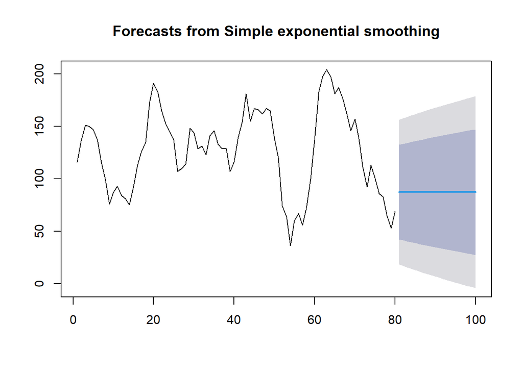

```r
#Cara 1 (fungsi ses)
ses.1 <- ses(train.ts, h = 20, alpha = 0.2)
plot(ses.1)
```

```r
ses.1
```

```
##     Point Forecast    Lo 80    Hi 80       Lo 95    Hi 95
##  81       87.29544 42.15034 132.4405 18.25196485 156.3389
##  82       87.29544 41.25629 133.3346 16.88463465 157.7062
##  83       87.29544 40.37927 134.2116 15.54335599 159.0475
##  84       87.29544 39.51835 135.0725 14.22669422 160.3642
##  85       87.29544 38.67268 135.9182 12.93334173 161.6575
##  86       87.29544 37.84146 136.7494 11.66210272 162.9288
##  87       87.29544 37.02398 137.5669 10.41188026 164.1790
##  88       87.29544 36.21959 138.3713  9.18166524 165.4092
##  89       87.29544 35.42767 139.1632  7.97052679 166.6203
##  90       87.29544 34.64766 139.9432  6.77760405 167.8133
##  91       87.29544 33.87903 140.7118  5.60209906 168.9888
##  92       87.29544 33.12132 141.4696  4.44327043 170.1476
##  93       87.29544 32.37405 142.2168  3.30042794 171.2904
##  94       87.29544 31.63682 142.9541  2.17292770 172.4179
##  95       87.29544 30.90923 143.6816  1.06016793 173.5307
##  96       87.29544 30.19090 144.4000 -0.03841482 174.6293
##  97       87.29544 29.48150 145.1094 -1.12334898 175.7142
##  98       87.29544 28.78070 145.8102 -2.19513098 176.7860
##  99       87.29544 28.08819 146.5027 -3.25422782 177.8451
## 100       87.29544 27.40369 147.1872 -4.30107953 178.8920
```

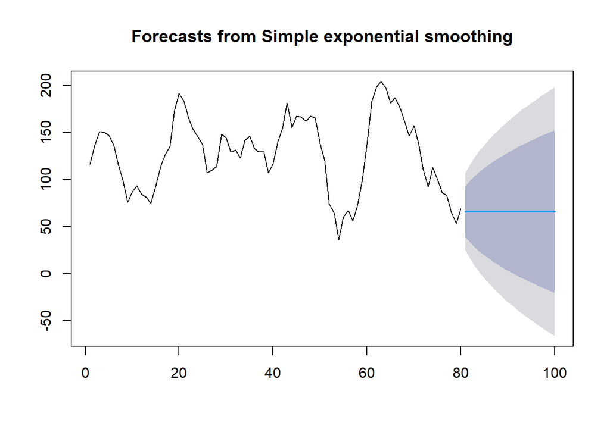

```r
ses.2<- ses(train.ts, h = 20, alpha = 0.7)
plot(ses.2)
```

```r
ses.2
```

```
##     Point Forecast       Lo 80     Hi 80      Lo 95    Hi 95
##  81       65.83279  38.9431734  92.72240  24.708672 106.9569
##  82       65.83279  33.0098306  98.65574  15.634407 116.0312
##  83       65.83279  27.9957467 103.66983   7.966027 123.6995
##  84       65.83279  23.5724419 108.09313   1.201166 130.4644
##  85       65.83279  19.5701463 112.09543  -4.919816 136.5854
##  86       65.83279  15.8875463 115.77803 -10.551867 142.2174
##  87       65.83279  12.4584278 119.20715 -15.796251 147.4618
##  88       65.83279   9.2366973 122.42888 -20.723463 152.3890
##  89       65.83279   6.1887385 125.47684 -25.384914 157.0505
##  90       65.83279   3.2891408 128.37643 -29.819466 161.4850
##  91       65.83279   0.5181422 131.14743 -34.057342 165.7229
##  92       65.83279  -2.1399868 133.80556 -38.122600 169.7882
##  93       65.83279  -4.6980086 136.36358 -42.034757 173.7003
##  94       65.83279  -7.1664478 138.83202 -45.809909 177.4755
##  95       65.83279  -9.5541047 141.21968 -49.461515 181.1271
##  96       65.83279 -11.8684266 143.53400 -53.000965 184.6665
##  97       65.83279 -14.1157823 145.78136 -56.437999 188.1036
##  98       65.83279 -16.3016692 147.96724 -59.781024 191.4466
##  99       65.83279 -18.4308709 150.09645 -63.037357 194.7029
## 100       65.83279 -20.5075813 152.17316 -66.213412 197.8790
```

Pada fungsi `ses()` , terdapat beberapa argumen yang umum digunakan, yaitu

- `y` : nilai data deret waktu
- `alpha` : parameter pemulusan utama (0–1), mengatur bobot data terbaru vs data lama.
- `beta` : parameter pemulusan tren.
- `gamma` : parameter pemulusan musiman.
- `h` : jumlah periode ke depan yang ingin diramalkan (forecast horizon).

  Kasus di atas merupakan contoh inisialisasi nilai parameter $\lambda$ dengan nilai `alpha` 0,2 dan 0,7 dan banyak periode data yang akan diramalkan adalah sebanyak 20 periode, menyesuaikan jumlah data uji.

Untuk mendapatkan gambar hasil pemulusan pada data latih dengan fungsi `ses()` , perlu digunakan fungsi `autoplot()` dan `autolayer()` dari *library packages* `ggplot2` .

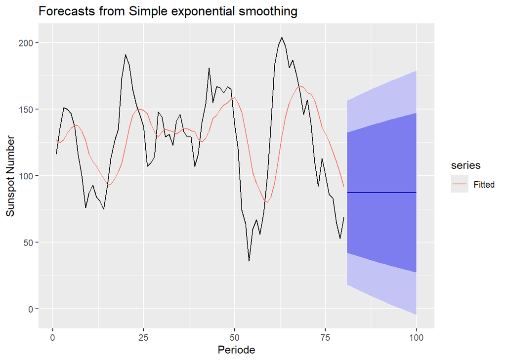

```r
autoplot(ses.1) +
  autolayer(fitted(ses.1), series="Fitted") +
  ylab("Sunspot Number") + xlab("Periode")
```

Selanjutnya akan digunakan fungsi `HoltWinters()` dengan nilai inisialisasi parameter dan panjang periode peramalan yang sama dengan fungsi `ses()` .

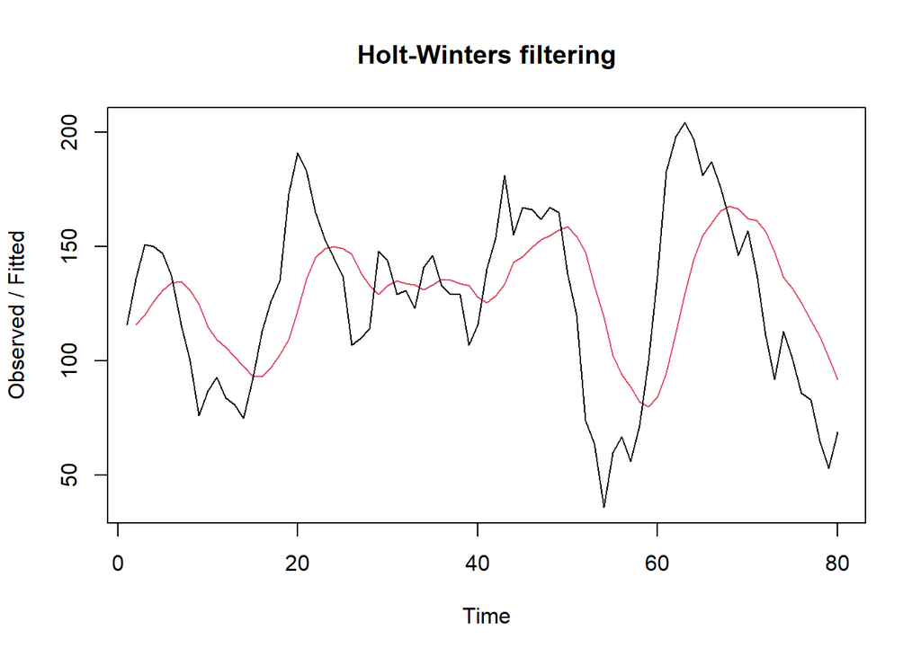

```r
#Cara 2 (fungsi Holtwinter)
ses1<- HoltWinters(train.ts, gamma = FALSE, beta = FALSE, alpha = 0.2)
plot(ses1)
```

```r
#ramalan
ramalan1<- forecast(ses1, h=20)
ramalan1
```

```
##     Point Forecast    Lo 80    Hi 80       Lo 95    Hi 95
##  81       87.29544 42.13228 132.4586 18.22434955 156.3665
##  82       87.29544 41.23787 133.3530 16.85647246 157.7344
##  83       87.29544 40.36051 134.2304 15.51465733 159.0762
##  84       87.29544 39.49924 135.0916 14.19746894 160.3934
##  85       87.29544 38.65323 135.9376 12.90359915 161.6873
##  86       87.29544 37.82168 136.7692 11.63185169 162.9590
##  87       87.29544 37.00387 137.5870 10.38112918 164.2097
##  88       87.29544 36.19916 138.3917  9.15042212 165.4405
##  89       87.29544 35.40692 139.1840  7.93879925 166.6521
##  90       87.29544 34.62660 139.9643  6.74539939 167.8455
##  91       87.29544 33.85767 140.7332  5.56942423 169.0214
##  92       87.29544 33.09965 141.4912  4.41013210 170.1807
##  93       87.29544 32.35209 142.2388  3.26683251 171.3240
##  94       87.29544 31.61456 142.9763  2.13888131 172.4520
##  95       87.29544 30.88667 143.7042  1.02567648 173.5652
##  96       87.29544 30.16806 144.4228 -0.07334567 174.6642
##  97       87.29544 29.45838 145.1325 -1.15871377 175.7496
##  98       87.29544 28.75730 145.8336 -2.23092444 176.8218
##  99       87.29544 28.06451 146.5264 -3.29044489 177.8813
## 100       87.29544 27.37974 147.2111 -4.33771530 178.9286
```

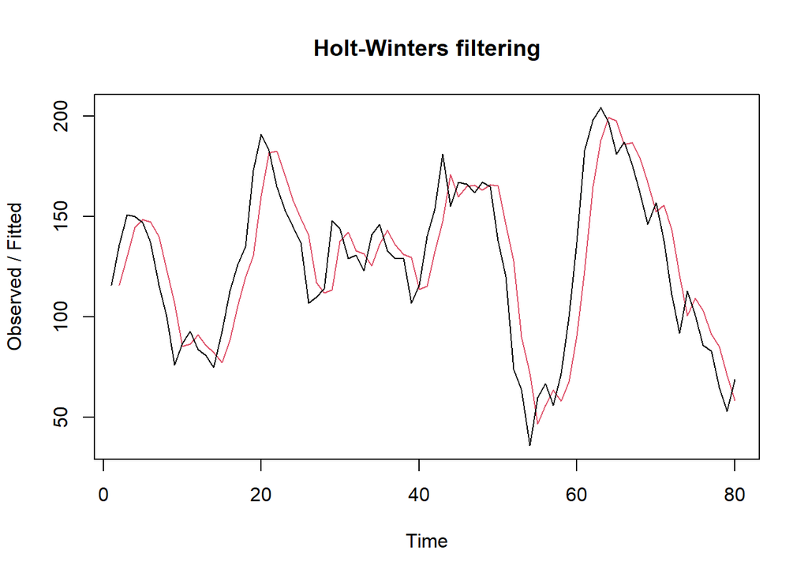

```r
ses2<- HoltWinters(train.ts, gamma = FALSE, beta = FALSE, alpha = 0.7)
plot(ses2)
```

```r
#ramalan
ramalan2<- forecast(ses2, h=20)
ramalan2
```

```
##     Point Forecast       Lo 80     Hi 80      Lo 95    Hi 95
##  81       65.83279  38.9459874  92.71959  24.712975 106.9526
##  82       65.83279  33.0132655  98.65231  15.639660 116.0259
##  83       65.83279  27.9997063 103.66587   7.972083 123.6935
##  84       65.83279  23.5768644 108.08871   1.207930 130.4576
##  85       65.83279  19.5749877 112.09059  -4.912412 136.5780
##  86       65.83279  15.8927730 115.77280 -10.543874 142.2094
##  87       65.83279  12.4640134 119.20156 -15.787709 147.4533
##  88       65.83279   9.2426200 122.42295 -20.714405 152.3800
##  89       65.83279   6.1949802 125.47059 -25.375368 157.0409
##  90       65.83279   3.2956860 128.36989 -29.809456 161.4750
##  91       65.83279   0.5249773 131.14060 -34.046889 165.7125
##  92       65.83279  -2.1328735 133.79845 -38.111721 169.7773
##  93       65.83279  -4.6906276 136.35620 -42.023468 173.6890
##  94       65.83279  -7.1588085 138.82438 -45.798225 177.4638
##  95       65.83279  -9.5462155 141.21179 -49.449449 181.1150
##  96       65.83279 -11.8602952 143.52587 -52.988529 184.6541
##  97       65.83279 -14.1074158 145.77299 -56.425203 188.0908
##  98       65.83279 -16.2930739 147.95865 -59.767879 191.4335
##  99       65.83279 -18.4220528 150.08763 -63.023871 194.6894
## 100       65.83279 -20.4985458 152.16412 -66.199593 197.8652
```

Fungsi `HoltWinters` memiliki argumen yang sama dengan fungsi `ses()` . Argumen-argumen kedua fungsi dapat dilihat lebih lanjut dengan `?ses()` atau `?HoltWinters` .

Nilai parameter $\alpha$ dari kedua fungsi dapat dioptimalkan menyesuaikan dari *error*-nya paling minimumnya. Caranya adalah dengan membuat parameter $\alpha =$ `NULL` .

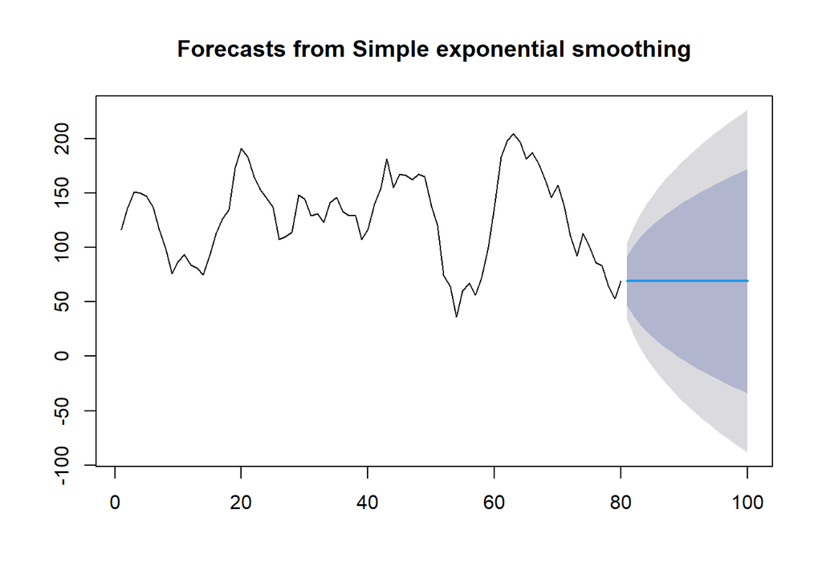

```r
#SES
ses.opt <- ses(train.ts, h = 20, alpha = NULL)
plot(ses.opt)
```

```r
ses.opt
```

```
##     Point Forecast        Lo 80     Hi 80      Lo 95    Hi 95
##  81        68.9984  45.97947080  92.01733  33.793986 104.2028
##  82        68.9984  36.44634616 101.55045  19.214330 118.7825
##  83        68.9984  29.13110367 108.86570   8.026632 129.9702
##  84        68.9984  22.96399522 115.03280  -1.405147 139.4019
##  85        68.9984  17.53062824 120.46617  -9.714764 147.7116
##  86        68.9984  12.61846885 125.37833 -17.227264 155.2241
##  87        68.9984   8.10125933 129.89554 -24.135740 162.1325
##  88        68.9984   3.89673452 134.10007 -30.566005 168.5628
##  89        68.9984  -0.05224775 138.04905 -36.605453 174.6023
##  90        68.9984  -3.78729269 141.78409 -42.317711 180.3145
##  91        68.9984  -7.33980908 145.33661 -47.750816 185.7476
##  92        68.9984 -10.73419855 148.73100 -52.942087 190.9389
##  93        68.9984 -13.98986650 151.98667 -57.921201 195.9180
##  94        68.9984 -17.12254683 155.11935 -62.712222 200.7090
##  95        68.9984 -20.14520655 158.14201 -67.334981 205.3318
##  96        68.9984 -23.06868258 161.06548 -71.806052 209.8029
##  97        68.9984 -25.90214162 163.89894 -76.139454 214.1363
##  98        68.9984 -28.65341977 166.65022 -80.347170 218.3440
##  99        68.9984 -31.32927819 169.32608 -84.439543 222.4363
## 100        68.9984 -33.93559883 171.93240 -88.425566 226.4224
```

```r
#Lamda Optimum Holt Winter
HWopt<- HoltWinters(train.ts, gamma = FALSE, beta = FALSE,alpha = NULL)
HWopt
```

```
## Holt-Winters exponential smoothing without trend and without seasonal component.
##
## Call:
## HoltWinters(x = train.ts, alpha = NULL, beta = FALSE, gamma = FALSE)
##
## Smoothing parameters:
##  alpha: 0.99992
##  beta : FALSE
##  gamma: FALSE
##
## Coefficients:
##       [,1]
## a 68.99872
```

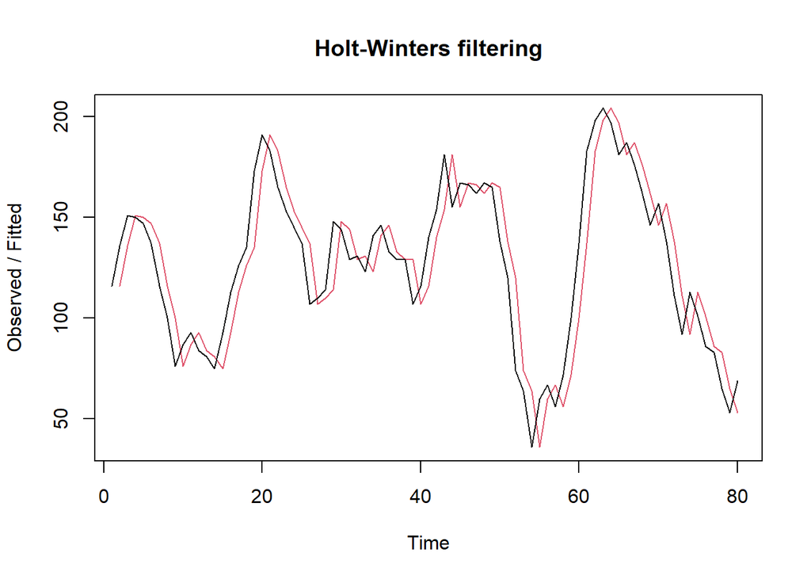

```r
plot(HWopt)
```

```r
#ramalan
ramalanopt<- forecast(HWopt, h=20)
ramalanopt
```

```
##     Point Forecast        Lo 80     Hi 80      Lo 95    Hi 95
##  81       68.99872  45.99274580  92.00469  33.814119 104.1833
##  82       68.99872  36.46466156 101.53278  19.242172 118.7553
##  83       68.99872  29.15333049 108.84411   8.060456 129.9370
##  84       68.99872  22.98953428 115.00790  -1.366257 139.3637
##  85       68.99872  17.55909252 120.43835  -9.671401 147.6688
##  86       68.99872  12.64958177 125.34786 -17.179850 155.1773
##  87       68.99872   8.13481047 129.86263 -24.084597 162.0820
##  88       68.99872   3.93255685 134.06488 -30.511389 168.5088
##  89       68.99872  -0.01429102 138.01173 -36.547572 174.5450
##  90       68.99872  -3.74731626 141.74476 -42.256741 180.2542
##  91       68.99872  -7.29791095 145.29535 -47.686907 185.6843
##  92       68.99872 -10.69046369 148.68790 -52.875369 190.8728
##  93       68.99872 -13.94436952 151.94181 -57.851789 195.8492
##  94       68.99872 -17.07535392 155.07279 -62.640216 200.6377
##  95       68.99872 -20.09637696 158.09382 -67.260472 205.2579
##  96       68.99872 -23.01826976 161.01571 -71.729121 209.7266
##  97       68.99872 -25.85019410 163.84763 -76.060176 214.0576
##  98       68.99872 -28.59998188 166.59742 -80.265613 218.2631
##  99       68.99872 -31.27439060 169.27183 -84.355769 222.3532
## 100       68.99872 -33.87929909 171.87674 -88.339632 226.3371
```

Nilai $\alpha$ optimum yang dihasilkan mendekati 1. Hal ini menunjukkan bahwa data bintik matahari sangat dipengaruhi oleh nilai pengamatan terakhir, sehingga model cenderung menyerupai *naive forecast* di mana ramalan hampir sama dengan data terakhir. Karakteristik ini umum ditemukan pada deret waktu dengan fluktuasi tinggi.

Setelah dilakukan peramalan, akan dilakukan perhitungan keakuratan hasil peramalan. Perhitungan akurasi ini dilakukan baik pada data latih dan data uji.

#### Akurasi Data Latih

Perhitungan akurasi data dapat dilakukan dengan cara langsung maupun manual. Secara langsung, nilai akurasi dapat diambil dari objek yang tersimpan pada hasil SES, yaitu *sum of squared errors* (SSE). Nilai akurasi lain dapat dihitung pula dari nilai SSE tersebut.

```r
#Keakuratan Metode
#Pada data training

# SES dengan alpha = 0.2
SSE1<-ses1$SSE
MSE1<-ses1$SSE/length(train.ts)
RMSE1<-sqrt(MSE1)

akurasi1 <- matrix(c(SSE1,MSE1,RMSE1))
row.names(akurasi1)<- c("SSE", "MSE", "RMSE")
colnames(akurasi1) <- c("Akurasi lamda=0.2")
akurasi1
```

```
##      Akurasi lamda=0.2
## SSE         97131.1247
## MSE          1214.1391
## RMSE           34.8445
```

```r
# SES dengan alpha = 0.7
SSE2<-ses2$SSE
MSE2<-ses2$SSE/length(train.ts)
RMSE2<-sqrt(MSE2)

akurasi2 <- matrix(c(SSE2,MSE2,RMSE2))
row.names(akurasi2)<- c("SSE", "MSE", "RMSE")
colnames(akurasi2) <- c("Akurasi lamda=0.7")
akurasi2
```

```
##      Akurasi lamda=0.7
## SSE        34397.13857
## MSE          429.96423
## RMSE          20.73558
```

```r
#Cara Manual
# Alpha = 0.2
fitted1<-ramalan1$fitted
sisaan1<-ramalan1$residuals
head(sisaan1)
```

```
## Time Series:
## Start = 1
## End = 6
## Frequency = 1
## [1]     NA 20.000 31.000 23.800 16.040  2.832
```

```r
resid1<-training$Sunspot-ramalan1$fitted
head(resid1)
```

```
## Time Series:
## Start = 1
## End = 6
## Frequency = 1
## [1]     NA 20.000 31.000 23.800 16.040  2.832
```

```r
SSE.1=sum(sisaan1[2:length(train.ts)]^2)
SSE.1
```

```
## [1] 97131.12
```

```r
MSE.1 = SSE.1/length(train.ts)
MSE.1
```

```
## [1] 1214.139
```

```r
MAPE.1 = sum(abs(sisaan1[2:length(train.ts)]/train.ts[2:length(train.ts)])*
               100)/length(train.ts)
MAPE.1
```

```
## [1] 27.02797
```

```r
akurasi.1 <- matrix(c(SSE.1,MSE.1,MAPE.1))
row.names(akurasi.1)<- c("SSE", "MSE", "MAPE")
colnames(akurasi.1) <- c("Akurasi lamda=0.2")
akurasi.1
```

```
##      Akurasi lamda=0.2
## SSE        97131.12468
## MSE         1214.13906
## MAPE          27.02797
```

```r
# Alpha = 0.7
fitted2<-ramalan2$fitted
sisaan2<-ramalan2$residuals
head(sisaan2)
```

```
## Time Series:
## Start = 1
## End = 6
## Frequency = 1
## [1]      NA  20.000  21.000   5.300  -1.410 -10.423
```

```r
resid2<-training$Sunspot-ramalan2$fitted
head(resid2)
```

```
## Time Series:
## Start = 1
## End = 6
## Frequency = 1
## [1]      NA  20.000  21.000   5.300  -1.410 -10.423
```

```r
SSE.2=sum(sisaan2[2:length(train.ts)]^2)
SSE.2
```

```
## [1] 34397.14
```

```r
MSE.2 = SSE.2/length(train.ts)
MSE.2
```

```
## [1] 429.9642
```

```r
MAPE.2 = sum(abs(sisaan2[2:length(train.ts)]/train.ts[2:length(train.ts)])*
               100)/length(train.ts)
MAPE.2
```

```
## [1] 15.2002
```

```r
akurasi.2 <- matrix(c(SSE.2,MSE.2,MAPE.2))
row.names(akurasi.2)<- c("SSE", "MSE", "MAPE")
colnames(akurasi.2) <- c("Akurasi lamda=0.7")
akurasi.2
```

```
##      Akurasi lamda=0.7
## SSE         34397.1386
## MSE           429.9642
## MAPE           15.2002
```

Berdasarkan nilai SSE, MSE, RMSE, dan MAPE di antara kedua parameter, pada data ini nilai parameter $\lambda=0,7$ menghasilkan akurasi yang **lebih baik** dibanding $\lambda=0,2$ , ditunjukkan oleh nilai masing-masing ukuran akurasi yang lebih kecil. Hasil ini berbeda dengan data yang bersifat stasioner, karena data bintik matahari berubah cepat sehingga pembobotan yang lebih besar pada pengamatan terbaru justru lebih menguntungkan.

#### Akurasi Data Uji

Akurasi data uji dapat dihitung dengan cara yang hampir sama dengan perhitungan akurasi data latih.

```r
# jumlah observasi uji
n_test <- nrow(testing)

# error (ramalan - aktual), samakan panjang dan tipe numeric
e1   <- as.numeric(ramalan1$mean)[1:n_test] - as.numeric(testing$Sunspot)
e2   <- as.numeric(ramalan2$mean)[1:n_test] - as.numeric(testing$Sunspot)
eopt <- as.numeric(ramalanopt$mean)[1:n_test] - as.numeric(testing$Sunspot)

# SSE / MSE / RMSE untuk masing-masing model (abaikan NA)
SSEtesting1  <- sum(e1^2,  na.rm = TRUE)
MSEtesting1  <- mean(e1^2, na.rm = TRUE)
RMSEtesting1 <- sqrt(MSEtesting1)

SSEtesting2  <- sum(e2^2,  na.rm = TRUE)
MSEtesting2  <- mean(e2^2, na.rm = TRUE)
RMSEtesting2 <- sqrt(MSEtesting2)

SSEtestingopt  <- sum(eopt^2,  na.rm = TRUE)
MSEtestingopt  <- mean(eopt^2, na.rm = TRUE)
RMSEtestingopt <- sqrt(MSEtestingopt)

# Tabel ringkas
akurasitesting_SSE <- matrix(c(SSEtesting1, SSEtesting2, SSEtestingopt),
                             nrow = 3,
                             dimnames = list(c("SSE1","SSE2","SSEopt"), "Nilai"))
akurasitesting_MSE <- matrix(c(MSEtesting1, MSEtesting2, MSEtestingopt),
                             nrow = 3,
                             dimnames = list(c("MSE1","MSE2","MSEopt"), "Nilai"))
akurasitesting_RMSE <- matrix(c(RMSEtesting1, RMSEtesting2, RMSEtestingopt),
                              nrow = 3,
                              dimnames = list(c("RMSE1","RMSE2","RMSEopt"), "Nilai"))

akurasitesting_SSE
```

```
##            Nilai
## SSE1    91196.47
## SSE2   154370.40
## SSEopt 143893.16
```

```r
akurasitesting_MSE
```

```
##           Nilai
## MSE1   4559.824
## MSE2   7718.520
## MSEopt 7194.658
```

```r
akurasitesting_RMSE
```

```
##            Nilai
## RMSE1   67.52647
## RMSE2   87.85511
## RMSEopt 84.82133
```

Menarik untuk dicatat bahwa pada data uji urutan performa justru berbalik dari data latih: $\lambda=0,2$ menjadi yang terbaik. Penjelasannya adalah $\lambda$ kecil menghasilkan level akhir yang lebih halus dan lebih tinggi (sekitar 87), yang lebih dekat dengan rata-rata data uji, sedangkan $\lambda$ besar mengunci level pada nilai pengamatan terakhir data latih yang sedang berada di posisi rendah (sekitar 66).

Selain dengan cara di atas, perhitungan nilai akurasi dapat menggunakan fungsi `accuracy()` dari *package* `forecast` . Penggunaannya yaitu dengan menuliskan `accuracy(hasil ramalan, kondisi aktual)` . Contohnya adalah sebagai berikut.

```r
accuracy(ramalan1, testing$Sunspot)
```

```
##                     ME     RMSE      MAE       MPE     MAPE     MASE      ACF1
## Training set -1.816745 35.06434 28.02028 -11.48416 27.37010 1.903355 0.8605777
## Test set     62.854563 67.52647 63.68411  39.71954 40.76959 4.325920        NA
```

```r
accuracy(ramalan2, testing$Sunspot)
```

```
##                      ME     RMSE      MAE       MPE     MAPE     MASE      ACF1
## Training set -0.9071829 20.86640 16.62909 -3.607857 15.39260 1.129577 0.5953469
## Test set     84.3172127 87.85511 84.31721 54.540225 54.54022 5.727480        NA
```

```r
accuracy(ramalanopt, testing$Sunspot)
```

```
##                      ME     RMSE      MAE       MPE     MAPE     MASE      ACF1
## Training set -0.5950005 17.84760 14.72185 -2.222595 13.62763 1.000022 0.3464944
## Test set     81.1512806 84.82133 81.15128 52.354041 52.35404 5.512426        NA
```

## *Double Exponential Smoothing* (DES)

Metode pemulusan *Double Exponential Smoothing* (DES) digunakan untuk data yang memiliki pola tren. Metode DES adalah metode semacam SES, hanya saja dilakukan dua kali, yaitu pertama untuk tahapan ‘level’ dan kedua untuk tahapan ‘tren’. Pemulusan menggunakan metode ini akan menghasilkan peramalan tidak konstan untuk periode berikutnya.

Pemulusan dengan metode DES kali ini akan menggunakan fungsi `HoltWinters()` . Jika sebelumnya nilai argumen `beta` dibuat `FALSE` , kali ini argumen tersebut akan diinisialisasi bersamaan dengan nilai `alpha` .

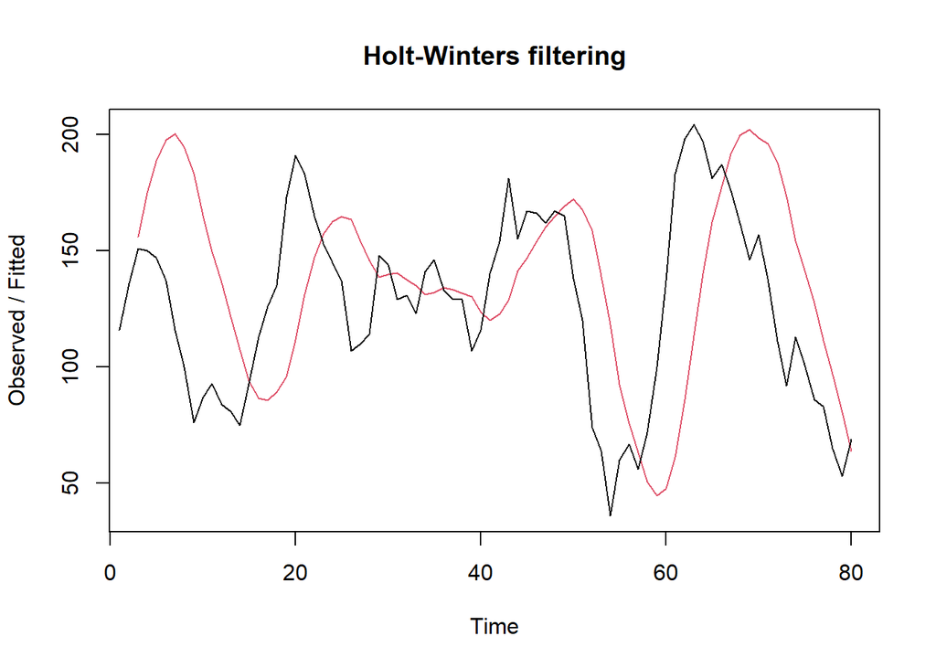

```r
#Lamda=0.2 dan gamma=0.2
des.1<- HoltWinters(train.ts, gamma = FALSE, beta = 0.2, alpha = 0.2)
plot(des.1)
```

```r
#ramalan
ramalandes1<- forecast(des.1, h=20)
ramalandes1
```

```
##     Point Forecast       Lo 80     Hi 80      Lo 95    Hi 95
##  81     53.9377784   -7.807152 115.68271  -40.49294 148.3685
##  82     42.9676836  -20.530606 106.46597  -54.14457 140.0799
##  83     31.9975887  -33.812196  97.80737  -68.64979 132.6450
##  84     21.0274939  -47.684378  89.73937  -84.05825 126.1132
##  85     10.0573990  -62.160418  82.27522 -100.39022 120.5050
##  86     -0.9126959  -77.237023  75.41163 -117.64068 115.8153
##  87    -11.8827907  -92.898163  69.13258 -135.78511 112.0195
##  88    -22.8528856 -109.119194  63.41342 -154.78582 109.0800
##  89    -33.8229804 -125.870570  58.22461 -174.59762 106.9517
##  90    -44.7930753 -143.120787  53.53464 -195.17233 105.5862
##  91    -55.7631701 -160.838457  49.31212 -216.46195 104.9356
##  92    -66.7332650 -178.993632  45.52710 -238.42068 104.9542
##  93    -77.7033599 -197.558525  42.15181 -261.00602 105.5993
##  94    -88.6734547 -216.507830  39.16092 -284.17926 106.8324
##  95    -99.6435496 -235.818771  36.53167 -307.90558 108.6185
##  96   -110.6136444 -255.470989  34.24370 -332.15383 110.9265
##  97   -121.5837393 -275.446358  32.27888 -356.89631 113.7288
##  98   -132.5538342 -295.728759  30.62109 -382.10835 117.0007
##  99   -143.5239290 -316.303854  29.25600 -407.76802 120.7202
## 100   -154.4940239 -337.158864  28.17082 -433.85579 124.8677
```

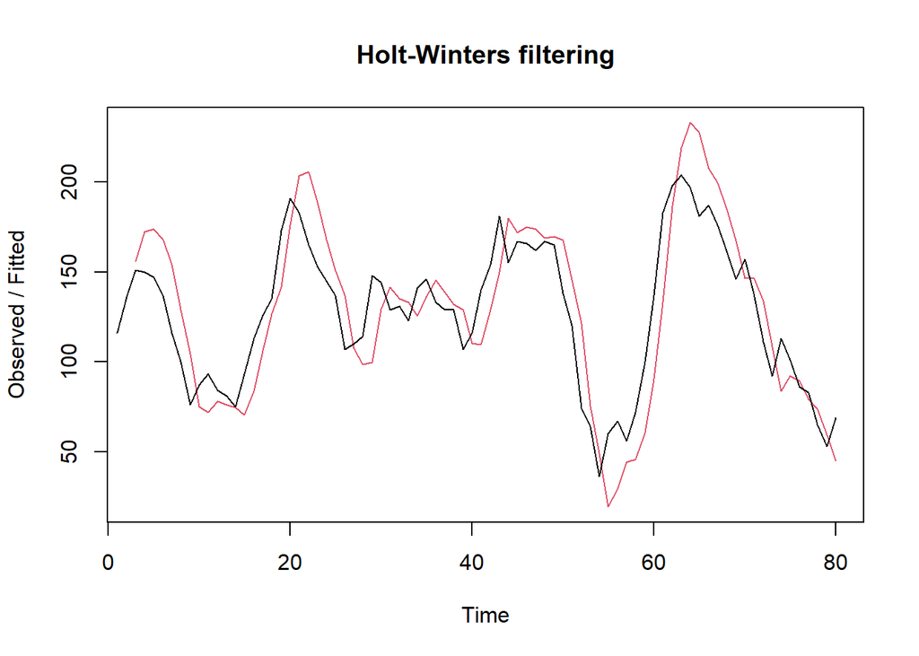

```r
#Lamda=0.6 dan gamma=0.3
des.2<- HoltWinters(train.ts, gamma = FALSE, beta = 0.3, alpha = 0.6)
plot(des.2)
```

```r
#ramalan
ramalandes2<- forecast(des.2, h=20)
ramalandes2
```

```
##     Point Forecast       Lo 80     Hi 80       Lo 95    Hi 95
##  81      53.339581   22.710963  83.96820    6.497153 100.1820
##  82      47.249520    8.405477  86.09356  -12.157317 106.6564
##  83      41.159459   -7.558339  89.87726  -33.347984 115.6669
##  84      35.069399  -24.868857  95.00765  -56.598253 126.7371
##  85      28.979338  -43.319771 101.27845  -81.592608 139.5513
##  86      22.889277  -62.772346 108.55090 -108.118870 153.8974
##  87      16.799217  -83.128965 116.72740 -136.027749 169.6262
##  88      10.709156 -104.317513 125.73582 -165.208953 186.6273
##  89       4.619095 -126.282327 135.52052 -195.577354 204.8155
##  90      -1.470965 -148.978845 146.03691 -227.064799 224.1229
##  91      -7.561026 -172.370312 157.24826 -259.615078 244.4930
##  92     -13.651086 -196.425677 169.12350 -293.180700 265.8785
##  93     -19.741147 -221.118193 181.63590 -327.720761 288.2385
##  94     -25.831208 -246.424456 194.76204 -363.199467 311.5371
##  95     -31.921268 -272.323724 208.48119 -399.585096 335.7426
##  96     -38.011329 -298.797415 222.77476 -436.849229 360.8266
##  97     -44.101390 -325.828734 237.62595 -474.966181 386.7634
##  98     -50.191450 -353.402387 253.01949 -513.912562 413.5297
##  99     -56.281511 -381.504357 268.94134 -553.666932 441.1039
## 100     -62.371572 -410.121724 285.37858 -594.209534 469.4664
```

Selanjutnya jika ingin membandingkan plot data latih dan data uji adalah sebagai berikut.

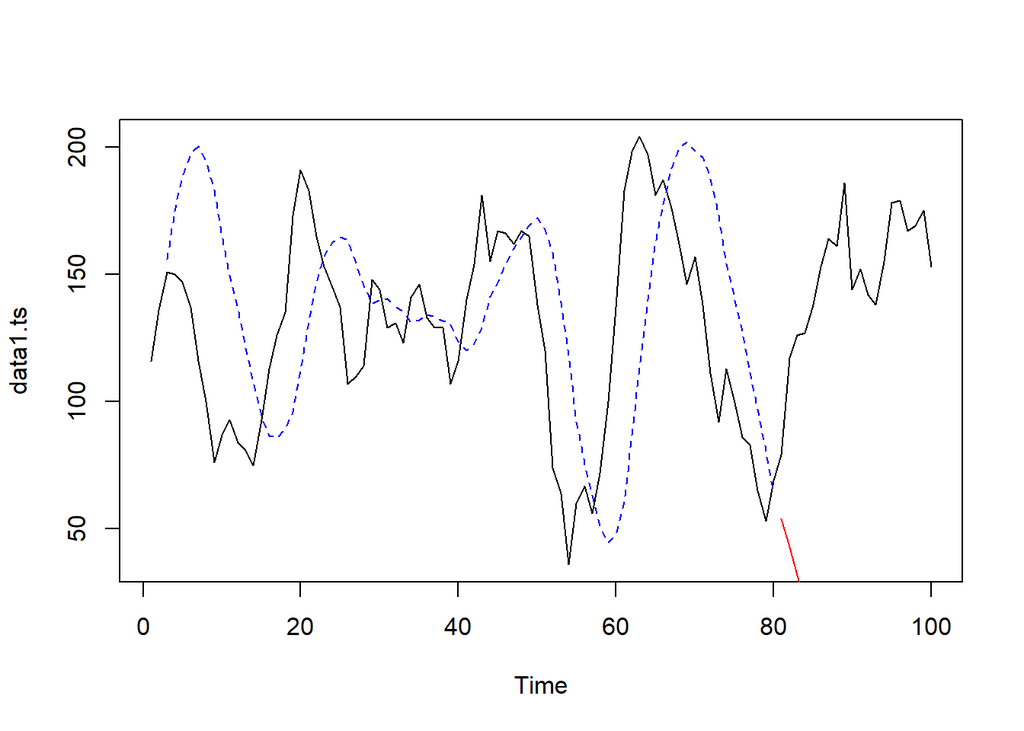

```r
plot(data1.ts)
lines(des.1$fitted[,1], lty=2, col="blue")
lines(ramalandes1$mean, col="red")
```

Untuk mendapatkan nilai parameter optimum dari DES, argumen `alpha` dan `beta` dapat dibuat `NULL` seperti berikut.

```r
#Lamda dan gamma optimum
des.opt<- HoltWinters(train.ts, gamma = FALSE)
des.opt
```

```
## Holt-Winters exponential smoothing with trend and without seasonal component.
##
## Call:
## HoltWinters(x = train.ts, gamma = FALSE)
##
## Smoothing parameters:
##  alpha: 1
##  beta : 0.4442568
##  gamma: FALSE
##
## Coefficients:
##         [,1]
## a 69.0000000
## b  0.5084937
```

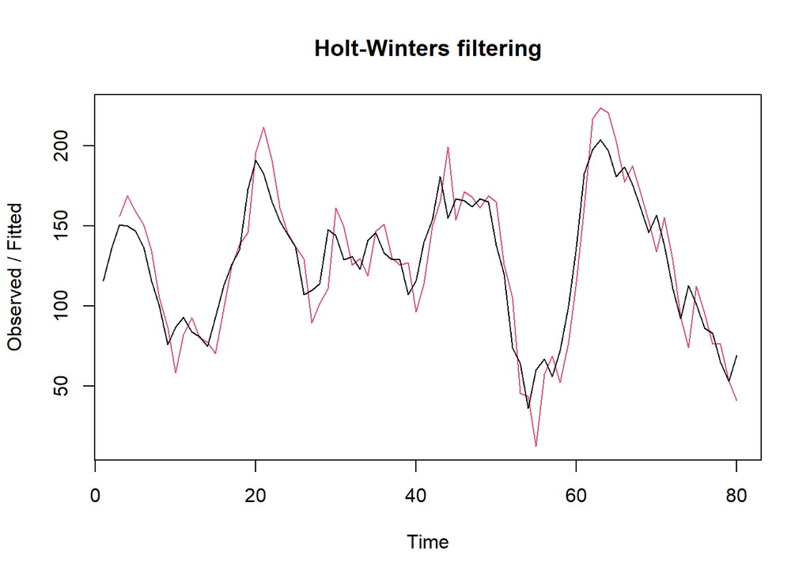

```r
plot(des.opt)
```

```r
#ramalan
ramalandesopt<- forecast(des.opt, h=20)
ramalandesopt
```

```
##     Point Forecast       Lo 80     Hi 80       Lo 95     Hi 95
##  81       69.50849   45.969375  93.04761   33.508519  105.5085
##  82       70.01699   28.666603 111.36737    6.777032  133.2569
##  83       70.52548    9.812982 131.23798  -22.326273  163.3772
##  84       71.03397  -10.827279 152.89523  -54.162009  196.2300
##  85       71.54247  -33.216021 176.30096  -88.671816  231.7568
##  86       72.05096  -57.270156 201.37208 -125.728620  269.8305
##  87       72.55946  -82.903758 228.02267 -165.201013  310.3199
##  88       73.06795 -110.037579 256.17348 -206.967790  353.1037
##  89       73.57644 -138.600693 285.75358 -250.920483  398.0734
##  90       74.08494 -168.530053 316.69993 -296.962671  445.1325
##  91       74.59343 -199.769539 348.95640 -345.008521  494.1954
##  92       75.10192 -232.268973 382.47282 -394.981297  545.1851
##  93       75.61042 -265.983254 417.20409 -446.812021  598.0329
##  94       76.11891 -300.871618 453.10944 -500.438349  652.6762
##  95       76.62741 -336.897020 490.15183 -555.803628  709.0584
##  96       77.13590 -374.025630 528.29743 -612.856117  767.1279
##  97       77.64439 -412.226406 567.51519 -671.548343  826.8371
##  98       78.15289 -451.470742 607.77651 -731.836555  888.1423
##  99       78.66138 -491.732173 649.05493 -793.680280  951.0030
## 100       79.16987 -532.986124 691.32587 -857.041935 1015.3817
```

Selanjutnya akan dilakukan perhitungan akurasi pada data latih maupun data uji dengan ukuran akurasi SSE, MSE dan MAPE.

#### Akurasi Data Latih

```r
#Akurasi Data Training
ssedes.train1<-des.1$SSE
msedes.train1<-ssedes.train1/length(train.ts)
sisaandes1<-ramalandes1$residuals
head(sisaandes1)
```

```
## Time Series:
## Start = 1
## End = 6
## Frequency = 1
## [1]        NA        NA  -5.00000 -24.80000 -41.64800 -60.46048
```

```r
mapedes.train1 <- sum(abs(sisaandes1[3:length(train.ts)]/train.ts[3:length(train.ts)])
                      *100)/length(train.ts)

akurasides.1 <- matrix(c(ssedes.train1,msedes.train1,mapedes.train1))
row.names(akurasides.1)<- c("SSE", "MSE", "MAPE")
colnames(akurasides.1) <- c("Akurasi lamda=0.2 dan gamma=0.2")
akurasides.1
```

```
##      Akurasi lamda=0.2 dan gamma=0.2
## SSE                     186425.22974
## MSE                       2330.31537
## MAPE                        34.87249
```

```r
ssedes.train2<-des.2$SSE
msedes.train2<-ssedes.train2/length(train.ts)
sisaandes2<-ramalandes2$residuals
head(sisaandes2)
```

```
## Time Series:
## Start = 1
## End = 6
## Frequency = 1
## [1]        NA        NA  -5.00000 -22.10000 -26.96200 -31.05364
```

```r
mapedes.train2 <- sum(abs(sisaandes2[3:length(train.ts)]/train.ts[3:length(train.ts)])
                      *100)/length(train.ts)

akurasides.2 <- matrix(c(ssedes.train2,msedes.train2,mapedes.train2))
row.names(akurasides.2)<- c("SSE", "MSE", "MAPE")
colnames(akurasides.2) <- c("Akurasi lamda=0.6 dan gamma=0.3")
akurasides.2
```

```
##      Akurasi lamda=0.6 dan gamma=0.3
## SSE                      44251.18058
## MSE                        553.13976
## MAPE                        17.02576
```

Hasil akurasi dari data latih didapatkan skenario 2 dengan lamda=0.6 dan gamma=0.3 memiliki hasil yang jauh lebih baik, dengan MSE sekitar 553 dibandingkan skenario 1 yang mencapai sekitar 2330. Kembali terlihat bahwa parameter pemulusan yang besar lebih sesuai untuk data bintik matahari yang berfluktuasi cepat.

#### Akurasi Data Uji

```r
#Akurasi Data Testing
selisihdes1<-ramalandes1$mean-testing$Sunspot
selisihdes1
```

```
## Time Series:
## Start = 81
## End = 100
## Frequency = 1
##  [1]  -25.06222  -74.03232  -94.00241 -105.97251 -127.94260 -153.91270
##  [7] -175.88279 -183.85289 -219.82298 -188.79308 -207.76317 -208.73327
## [13] -215.70336 -243.67345 -277.64355 -289.61364 -288.58374 -301.55383
## [19] -318.52393 -307.49402
```

```r
SSEtestingdes1<-sum(selisihdes1^2)
MSEtestingdes1<-SSEtestingdes1/length(testing$Sunspot)
MAPEtestingdes1<-sum(abs(selisihdes1/testing$Sunspot)*100)/length(testing$Sunspot)

selisihdes2<-ramalandes2$mean-testing$Sunspot
selisihdes2
```

```
## Time Series:
## Start = 81
## End = 100
## Frequency = 1
##  [1]  -25.66042  -69.75048  -84.84054  -91.93060 -109.02066 -130.11072
##  [7] -147.20078 -150.29084 -181.38090 -145.47097 -159.56103 -155.65109
## [13] -157.74115 -180.83121 -209.92127 -217.01133 -211.10139 -219.19145
## [19] -231.28151 -215.37157
```

```r
SSEtestingdes2<-sum(selisihdes2^2)
MSEtestingdes2<-SSEtestingdes2/length(testing$Sunspot)
MAPEtestingdes2<-sum(abs(selisihdes2/testing$Sunspot)*100)/length(testing$Sunspot)

selisihdesopt<-ramalandesopt$mean-testing$Sunspot
selisihdesopt
```

```
## Time Series:
## Start = 81
## End = 100
## Frequency = 1
##  [1]   -9.491506  -46.983013  -55.474519  -55.966025  -66.457532  -80.949038
##  [7]  -91.440544  -87.932051 -112.423557  -69.915063  -77.406570  -66.898076
## [13]  -62.389582  -78.881089 -101.372595 -101.864101  -89.355608  -90.847114
## [19]  -96.338620  -73.830127
```

```r
SSEtestingdesopt<-sum(selisihdesopt^2)
MSEtestingdesopt<-SSEtestingdesopt/length(testing$Sunspot)
MAPEtestingdesopt<-sum(abs(selisihdesopt/testing$Sunspot)*100)/length(testing$Sunspot)

akurasitestingdes <-
  matrix(c(SSEtestingdes1,MSEtestingdes1,MAPEtestingdes1,SSEtestingdes2,MSEtestingdes2,
           MAPEtestingdes2,SSEtestingdesopt,MSEtestingdesopt,MAPEtestingdesopt),
         nrow=3,ncol=3)
row.names(akurasitestingdes)<- c("SSE", "MSE", "MAPE")
colnames(akurasitestingdes) <- c("des ske1","des ske2","des opt")
akurasitestingdes
```

```
##         des ske1     des ske2      des opt
## SSE  938762.7229 539218.05935 125301.20554
## MSE   46938.1361  26960.90297   6265.06028
## MAPE    128.3144     99.56306     48.96313
```

#### Perbandingan SES dan DES

```r
MSEfull <-
  matrix(c(MSEtesting1,MSEtesting2,MSEtestingopt,MSEtestingdes1,MSEtestingdes2,
           MSEtestingdesopt),nrow=3,ncol=2)
row.names(MSEfull)<- c("ske 1", "ske 2", "ske opt")
colnames(MSEfull) <- c("ses","des")
MSEfull
```

```
##              ses      des
## ske 1   4559.824 46938.14
## ske 2   7718.520 26960.90
## ske opt 7194.658  6265.06
```

Kedua metode dapat dibandingkan dengan menggunakan ukuran akurasi yang sama. Contoh di atas adalah perbandingan kedua metode dengan ukuran akurasi MSE. Hasilnya didapatkan metode **SES lebih baik** dibandingkan metode DES pada data ini, dilihat dari nilai MSE terkecil yang dicapai SES skenario 1 dengan $\lambda=0,2$. Hasil ini berbeda dengan contoh pada materi praktikum, dan penyebabnya adalah karakteristik data: bintik matahari tidak memiliki tren yang persisten, sehingga penambahan komponen tren pada DES tidak memberikan manfaat dan justru menambah galat pada peramalan jangka panjang.

## Kesimpulan

Berdasarkan seluruh analisis yang telah dilakukan pada data bilangan bintik matahari harian bagian ke-2 (observasi 101–200), diperoleh ringkasan sebagai berikut.

**Perbandingan pada data uji.** Urutan performa berbalik secara tajam. Metode yang mengekstrapolasi tren secara linear, yaitu DMA dan DES skenario 1 dan 2, menghasilkan galat sangat besar dengan MAPE di atas 99%, bahkan menghasilkan ramalan bernilai negatif yang tidak mungkin terjadi pada bilangan bintik matahari. Sebaliknya metode tanpa komponen tren memberikan hasil yang jauh lebih baik.

**Metode terbaik.** Berdasarkan metrik akurasi pada data uji, metode terbaik untuk data ini adalah **SES dengan $\lambda=0,2$**, dengan MSE sekitar 4560 dan MAPE sekitar 41%. Alasannya adalah:

1. Data bintik matahari tidak memiliki tren linear yang persisten, sehingga model tanpa komponen tren lebih tepat secara struktural.
2. Nilai $\lambda$ yang kecil menghasilkan level ramalan yang halus dan stabil, sehingga tidak terlalu terpengaruh oleh nilai ekstrem pada akhir data latih.
3. Ramalan yang konstan justru lebih aman untuk deret yang sangat berfluktuasi, karena tidak memperbesar galat seiring bertambahnya horizon peramalan.

**Catatan mengenai nilai MAPE.** Seluruh metode menghasilkan MAPE di atas 10%, yang menunjukkan bahwa data bintik matahari memang tergolong sulit diramalkan dengan metode pemulusan sederhana. Hal ini berbeda dengan data penjualan pada contoh praktikum yang MAPE-nya di bawah 10%. Untuk peramalan yang lebih akurat, deret ini umumnya memerlukan model yang mampu menangkap struktur autokorelasi secara eksplisit, misalnya model ARIMA.